# Day 3

### Review

**Data set**

- Collected information

**Individuals**

- *Something* the information is collected on

**Variables**

- Characteristics about the **individuals** we collected information from

**Qualitative (Categorical) variable**

- Values represent categories
  - Identifying labels/names
  - “Can I do math with this by default?”
    - “Is the math arbitrary?” (i.e., does the 1 in “rank 1 salesperson at Amazon” actually represent a quantity? or does it describe them?)

**Quantitative variable**

- Values represent meaningful numbers

Qualitative variables can be **ordinal** or **nominal**

**Ordinal variable**

- Categories/values of the variable have a natural ordering
  - Letter grade: A, B, C, D

**Nominal variable**

- Categories/values of the variable cannot be ordered
  - Degree programs

Quantitative variables can be **discrete** or **continuous**

**Discrete variable**

- A countable number of values (0, 1, 2, 3, 4, …)
  - Number of students in a classroom

**Continous variable**

- A continuous range of numbers (0, 0.1, 0.11, 0.111, …)
  - Temperature

Quantitative variables can be **Interval** or **Ratio**

**Interval level**

- Can’t make a meaningful ratio
- **Zero doesn’t mean absence**
- Temperature in Celsius/Fahrenheit (Does 0 mean there’s no heat?)

**Ratio level**

- Ratios **make sense**
- Zero **represents absence of the variable**
- If you’re 0 inches tall do you have height?

**Raw data isn’t entirely useful**

- Statistics is really good at **summarizing** and **visualizing** data
- Bar graph: One or more **categorical** variable

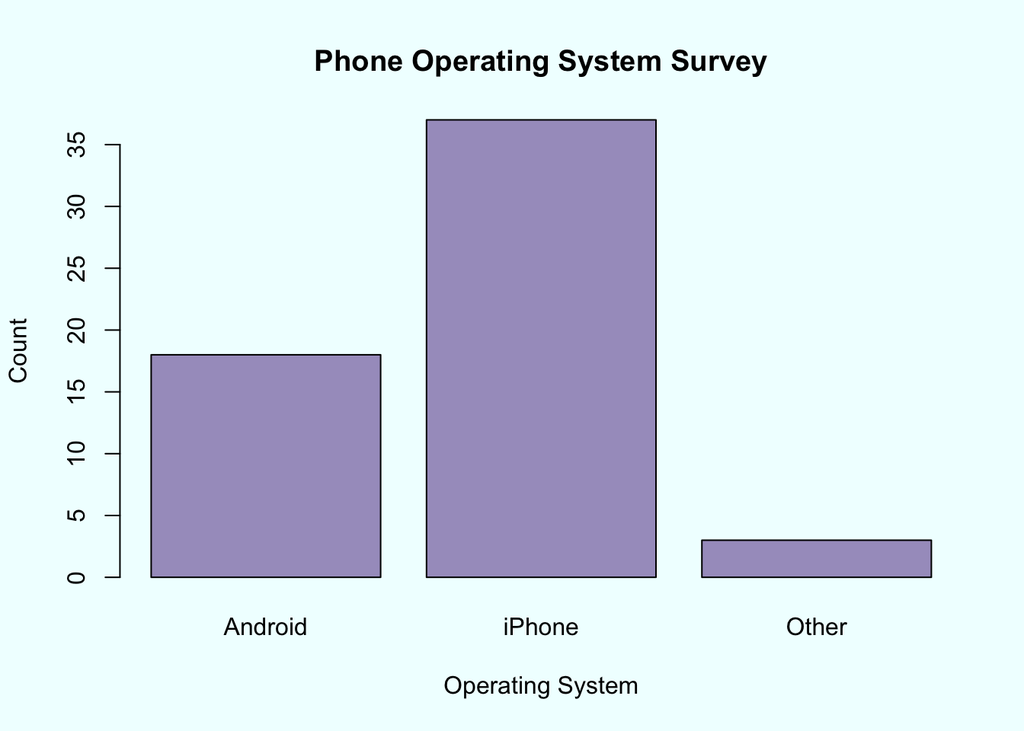

- Histogram: One **numerical** variable

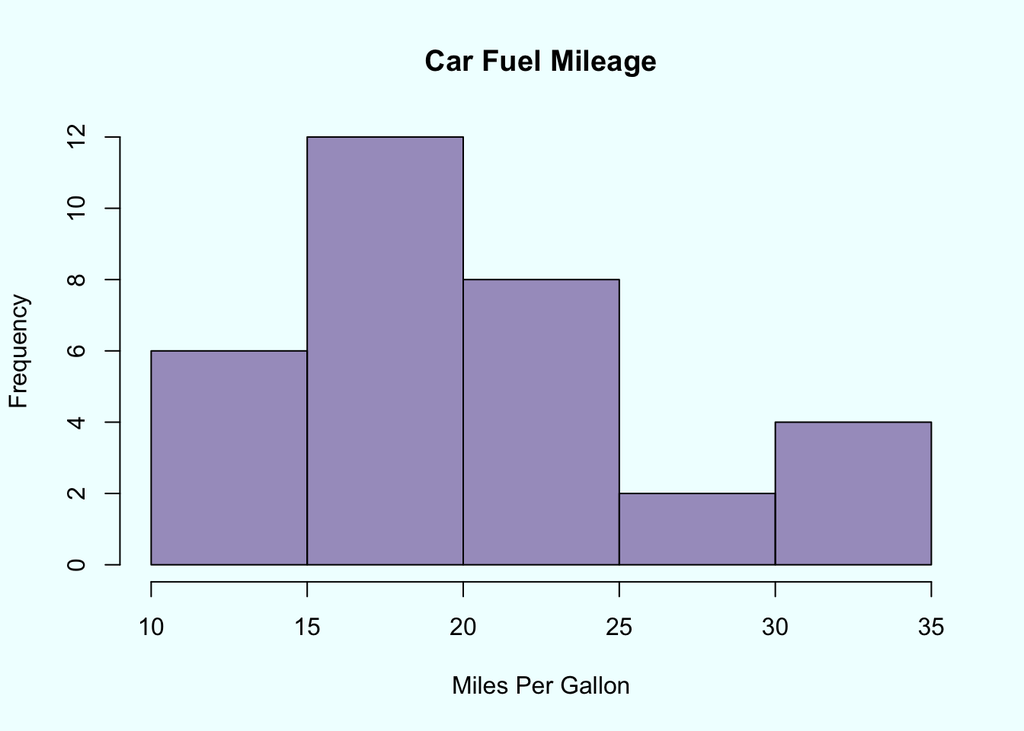

- Scatterplot: **More than one** numerical variable

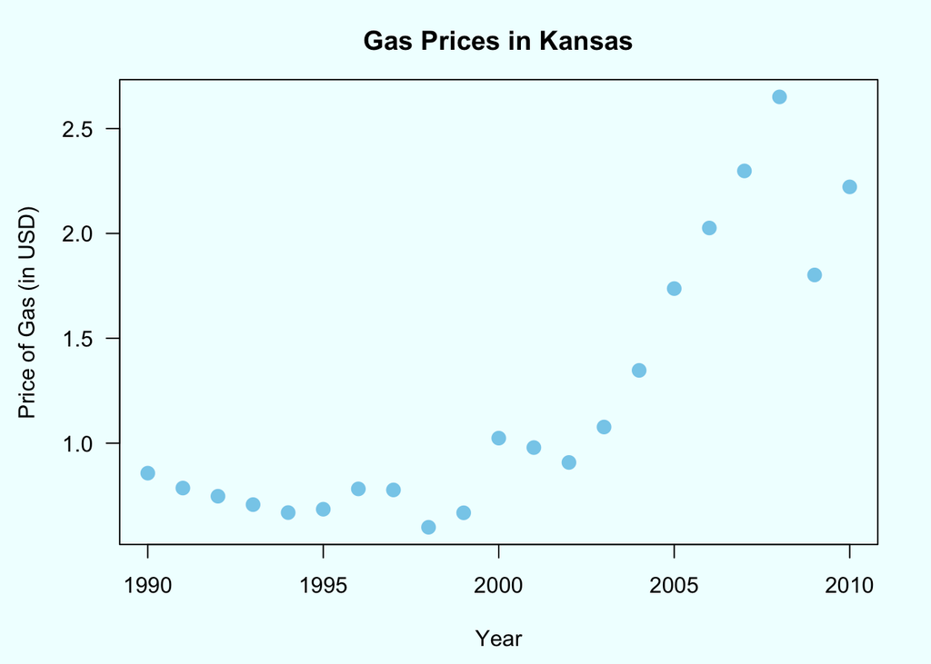

**Frequency distribution**

- Group data into categories
- Record the number of observations that fall into each category
- “How **frequently** do these variables occur in my sample?”

**Relative frequency distribution**

- Divide the number in each category by the total number of observations
- This gives us the **proportion** of units in each category
- “What **percentage** of my sample is represented by this variable?”

$$\begin{array}{|c|c|c|}
\hline
\text{Card Type} & \text{Frequency} & \text{Relative Frequency} \\
\hline
\text{Visa} & 4 & 4/12=0.33 \\
\hline
\text{American Express} & 3 & 3/12=0.25 \\
\hline
\text{Discover} & 2 & 2/12=0.167 \\
\hline
\text{Master Card} & 3 & 3/12=0.25 \\
\hline
\text{Total} & 12 & 12/12=1 \\
\hline
\end{array}$$

Count up how many times each variable occurs in the sample

- For each variable, divide the **occurrences** of the variable by the **sample total**
  - $4$ customers use Visa
  - $12$ customers total in the sample
  - ${4 \over 12}=0.33$
  - $0.33*100\%=33\%$

**Graphs are prettier than tables**

| Credit Card | Frequency | Relative Frequency |
| --- | --- | --- |
| Master Card | 11 | 0.22 |
| Visa | 23 | 0.46 |
| Am. Express | 9 | 0.18 |
| Discover | 7 | 0.14 |

One or more categorical variables $\rightarrow$ **bar graph**

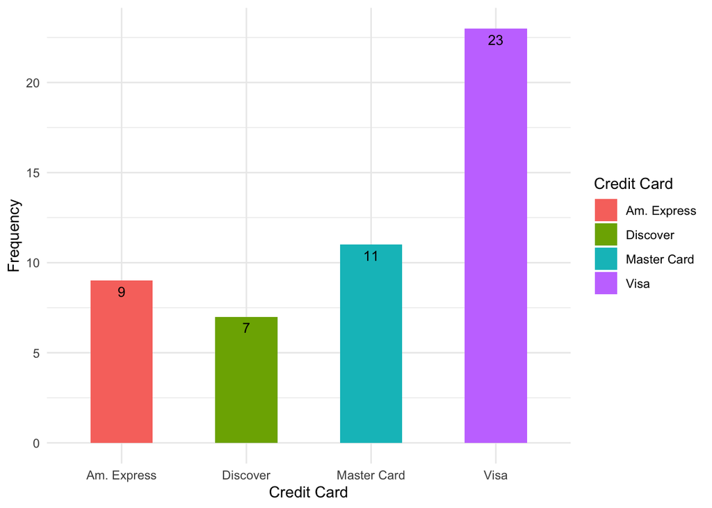

Bar graph using **relative frequency:**

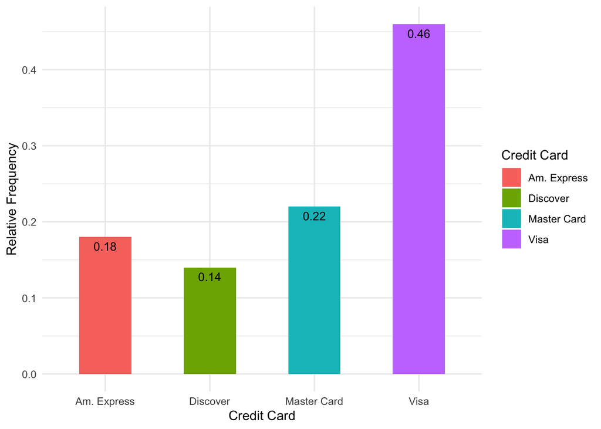

Flipped horizontal:

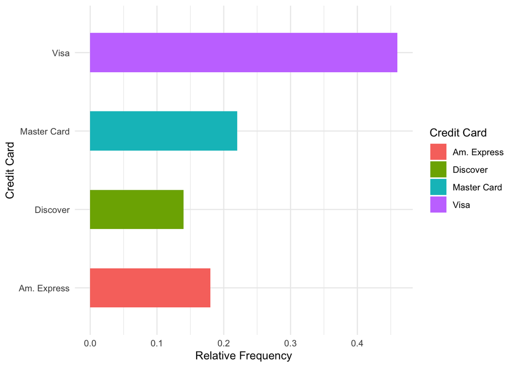

**Side-by-side** bar graphs can be used to **compare** two or more **categorical** variables with the *same* categories

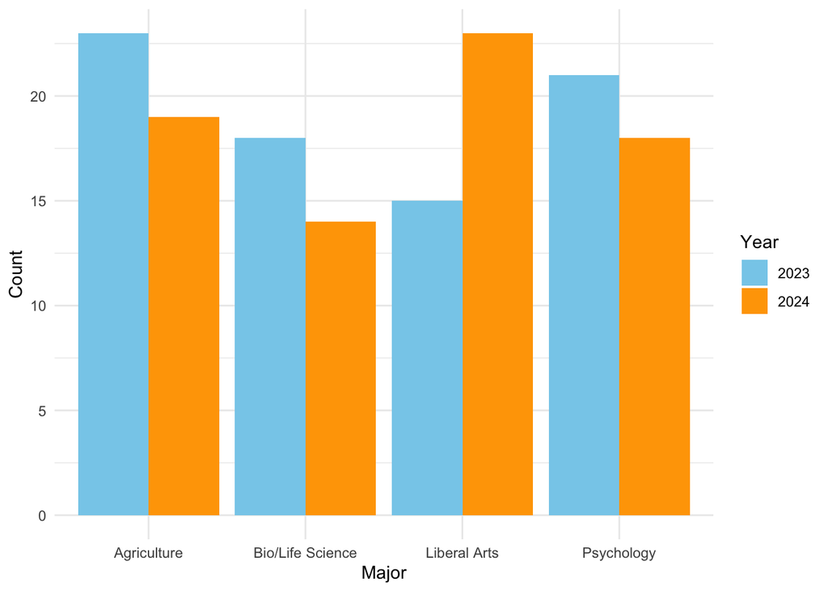

- Bar graphs showing frequency can be converted into pie charts
- Generally a pie chart will show relative frequency

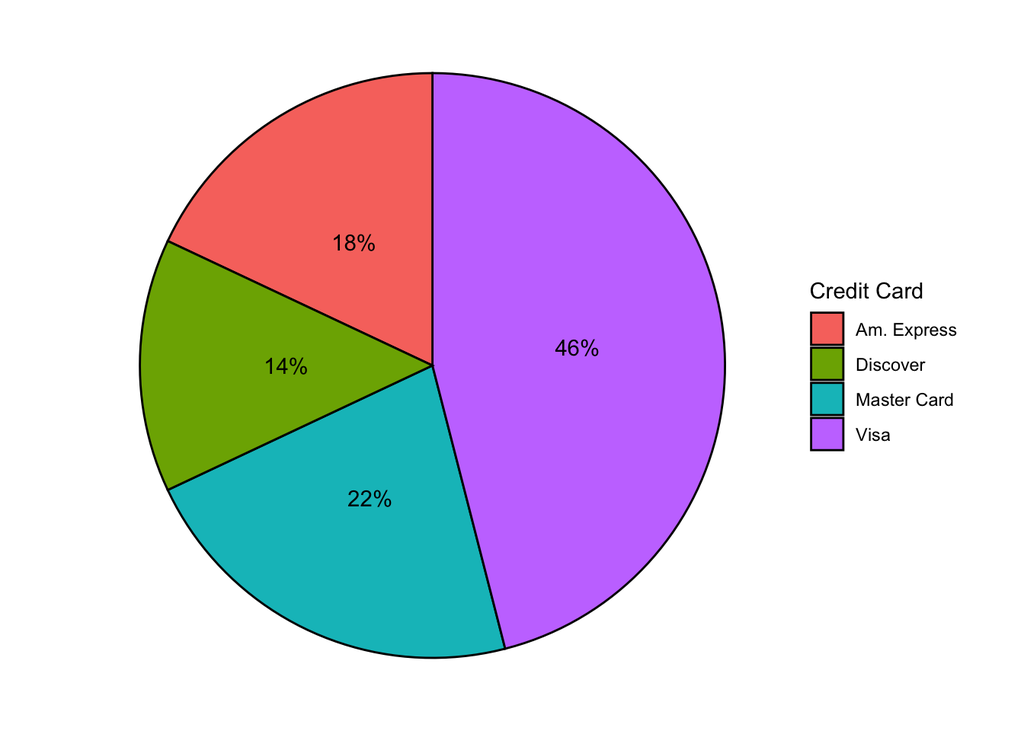

- They’re very pretty
  - Not very useful

**Questions?**

**Goals for Today:**

1. Introduce common visualizations of **one** quantitative variable
2. Interpret and analyze quantitative visualizations
3. Describe the shapes of data

## Graphical and Numerical Summaries

### Graphical Summaries Continued

We’ve looked at some **qualitative** (categorical) visualizations

- What about **quantitative** (numerical) visualizations?
- When we have **one** *quantitative* variable we have several options:
  - **Histograms**
  - **Steam-and-leaf plots**
  - **Dotplots**

With **two** quantitative variables we generally use a **scatterplot**

- We’ll talk about this at length in Chapter 4 (so not important right now)
- Side Note: we can use more than two quantitative variables in a scatterplot
  - It’s not very useful
  - Why? Can you think in 3 dimensions? What about 4? 5?

### Frequency Distribution

- In a study of the emissions of particulate matter, the amount of emission for **65** vehicles were recorded in a table:

| 0.7277937 | 2.463690 | 0.7277937 | 2.5947281 | 3.8522961 | 1.074112 | 2.246632 | 4.164161 | 6.7326499 | 1.946875 | 0.7565027 | 0.1961195 | 1.9468753 |
| --- | --- | --- | --- | --- | --- | --- | --- | --- | --- | --- | --- | --- |
| 2.3527465 | 1.534491 | 3.8318936 | 2.3527465 | 1.5295777 | 1.396259 | 1.843658 | 3.527220 | 1.9468753 | 1.867001 | 3.8318936 | 1.0741115 | 3.5272201 |
| 2.4636898 | 3.493271 | 4.1641607 | 0.3439388 | 2.2789063 | 1.534491 | 2.588917 | 5.044689 | 3.8522961 | 3.429113 | 1.5344915 | 2.5889175 | 0.7565027 |
| 1.6812509 | 3.359679 | 5.0446888 | 3.8896004 | 0.3439388 | 2.141205 | 2.429458 | 2.594728 | 0.1961195 | 1.607601 | 4.5418068 | 2.1389052 | 1.3655600 |
| 2.1389052 | 2.141205 | 1.4865026 | 3.4576303 | 4.1641607 | 1.614217 | 3.967066 | 3.889600 | 2.4636898 | 3.831894 | 5.0446888 | 0.7967509 | 1.5924308 |

- Population?
- Sample?
- Variables?
- Variable types?

**Quantitative** variables can *also* be summarized with a frequency distribution

- Define interval(s) for the data (referred to as **classes**/**class**)
- Record the number of observations that fall into each class

| Class | 0.00-0.99 | 1.00-1.99 | 2.00-2.99 | 3.00-3.99 | 4.00-4.99 | 5.00-5.99 | 6.00-6.99 |
| --- | --- | --- | --- | --- | --- | --- | --- |
| Frequency | 9 | 18 | 16 | 14 | 4 | 3 | 1 |

**Lower class limit**: the smallest value that can appear in that class

- Lower class limit of the **third** class?

**Upper class limit**: largest value that can appear in that class

- Upper class limit of the **first** class?

**Class width**: the **difference** between consecutive lower class limits

- Class width of the above frequency distribution?

There’s no “one” right way to choose the number of classes or the width for a frequency distribution

- There are general requirements however:
  - Every observation must fall into one of the classes
  - The classes must not overlap
  - The classes must be of equal width
  - There must be no gaps between classes
    - Even if there are no observations in a class it *must* be included in the frequency distribution

### Histograms

**Histogram**: visual representation of a frequency distribution

- **Not a bar graph**

Bar **height** (y-axis) represents **class frequency**

Bar **width** (x-axis) represents **class width**

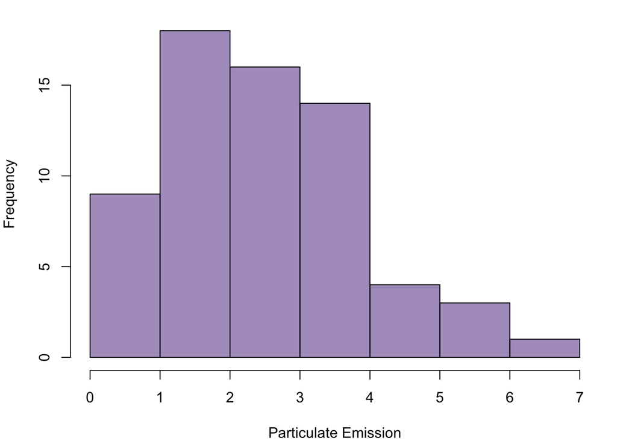

- Left edge of each bar corresponds to the lower class limit
- **No gaps between classes** so no gaps between bars of a histogram
  - If there are gaps between the bars what is it?
- This histogram has 7 classes
  - You can choose a different number of classes
  - You can choose different widths
  - Free will exists, there are no rules

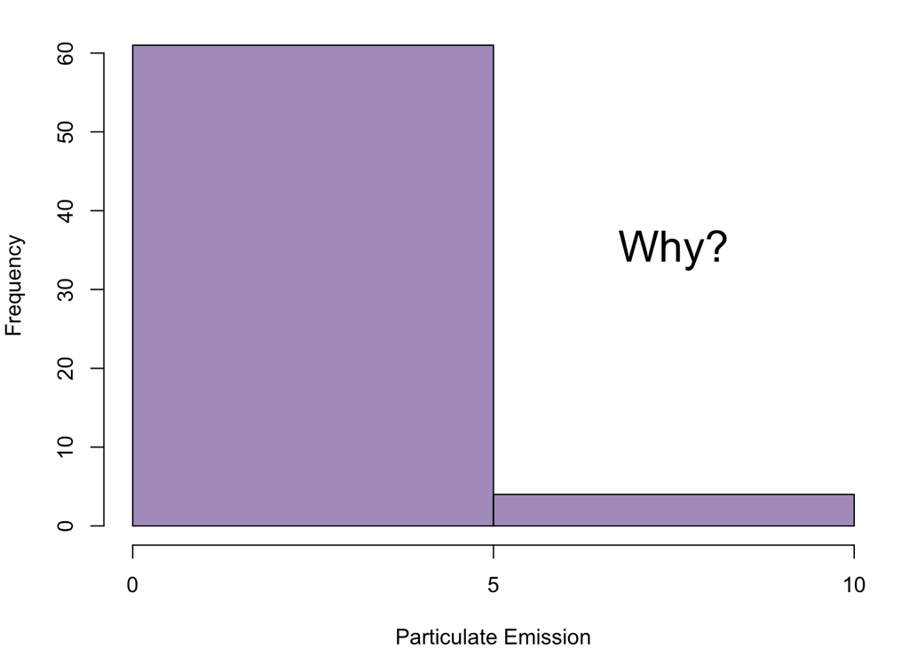

- It’s not wrong (it’s very unhinged behavior)
  - Is this interpretable though?
- We care about the **shape** of our data
  - This is the primary purpose of a histogram
  - So we want to **not** fail at that task
- The shape of our data can help us observe the **distribution** of our data

**Symmetric** - mirror image on both sides of it’s center

**Unimodal** - One peak/hump

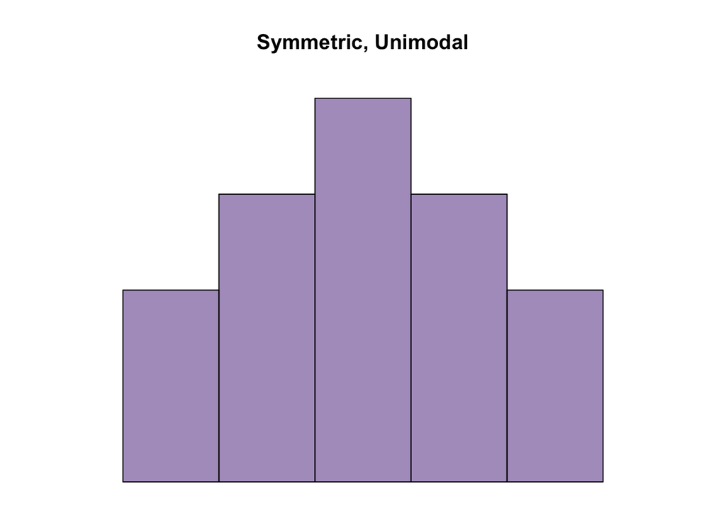

**Positively-skewed** - Long, narrow tail to the **right**

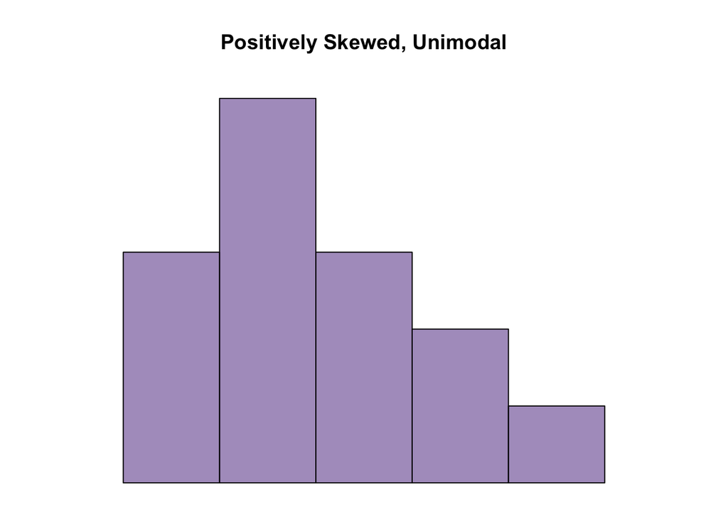

**Negatively-skewed** - Long, narrow tail to the **left**

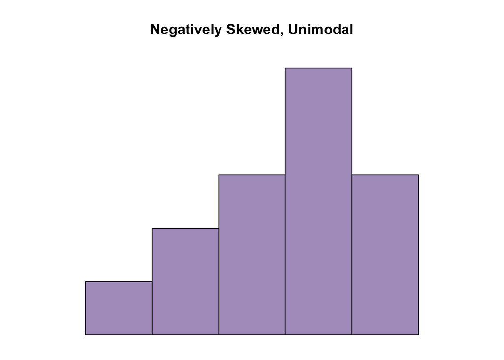

**Uniform** - box

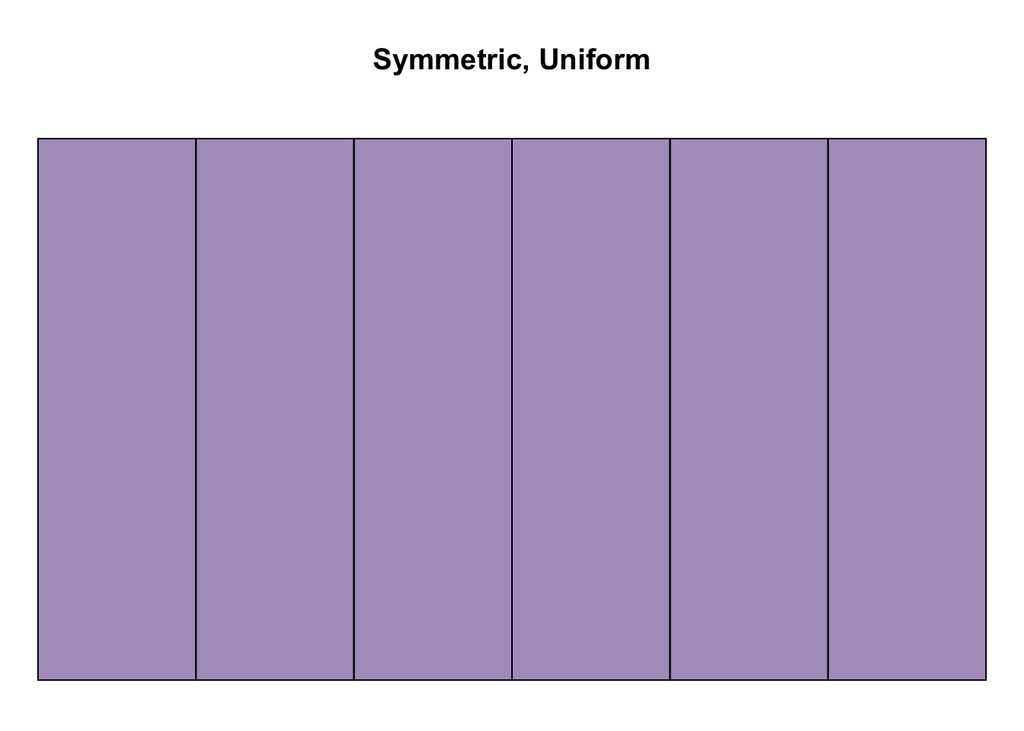

**Bimodal** - two peaks/humps

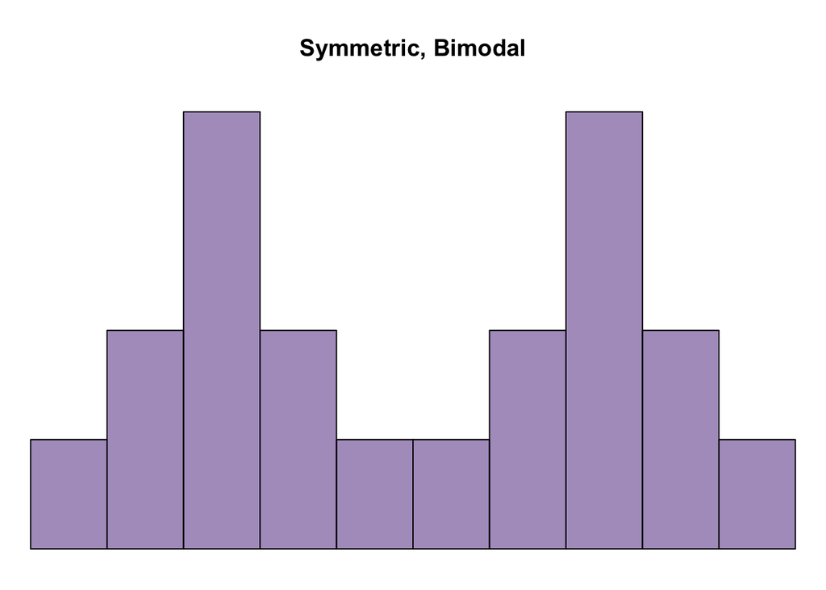

> Histogram showing the GPAs of a sample of students at a certain college

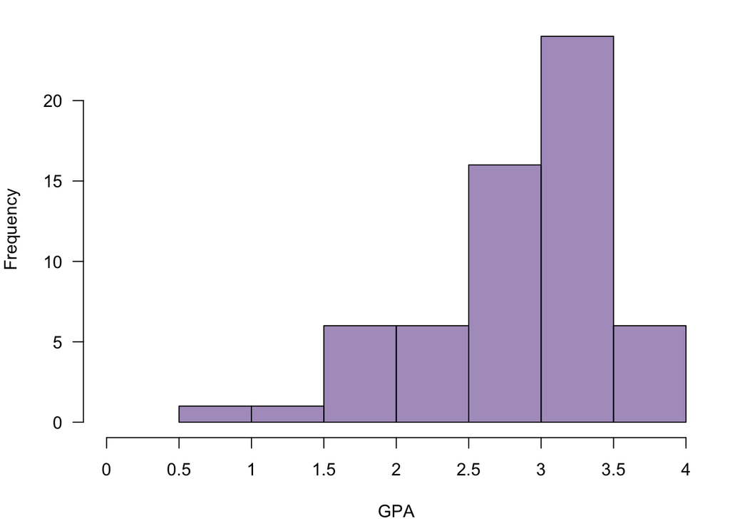

- Which class has the highest frequency?
- How many students were in the sample?
- What percentage of the students had GPAs between 2.0 and 3.0?
- Describe the shape of the above histogram.

> One of these histograms represents the age at death from natual causes, (heart attack, cancer, etc.)

> The other represents the age at death from accidents

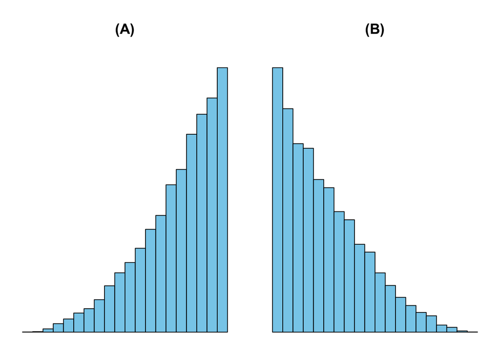

- Which represents the **age at death from accidents**?
  - Justify your answer
- Histograms can be used to summarize both small and large data sets
- Sometimes we prefer more detailed visualizations for smaller data sets
- **Stem-and-leaf plots** and **dotplots** are alternative summaries that display the actual values

### Stem-and-leaf plots

- Each observation should have *at least* **two** digits
  - The digit furthest to the **right** is the “leaf”
  - The digits to the **left** form the “stem”
- The data:

$$\begin{array}{|c|c|c|c|c|c|c|c|c|c|}
\hline
87 & 7 & 95 & 76 & 32 & 28 & 84 & 98 & 93 & 88\\
\hline
78 & 100 & 68 & 76 & 55 & 65 & 42 & 57 & 77 & 96 \\
\hline
\end{array}$$

- The stem-and-leaf plot:

$$\begin{array}{r|l}
0 & 7 \\
1 & \\
2 & 8 \\
3 & 2 \\
4 & 2 \\
5 & 5 \; 7 \\
6 & 5 \; 8 \\
7 & 6 \; 6 \; 7 \; 8 \\
8 & 4 \; 7 \; 8 \\
9 & 3 \; 5 \; 6 \; 8 \\
10 & 0
\end{array}$$

- Can you describe the shape of the data?

### Dotplots

- We can represent each observation by a dot above its value on a number line
- Data:

$$\begin{array}{|c|c|c|c|c|}
\hline
3 & 6 & 2 & 5 & 1 \\
\hline
2 & 3 & 4 & 3 & 4 \\
\hline
\end{array}$$

- Dotplot:

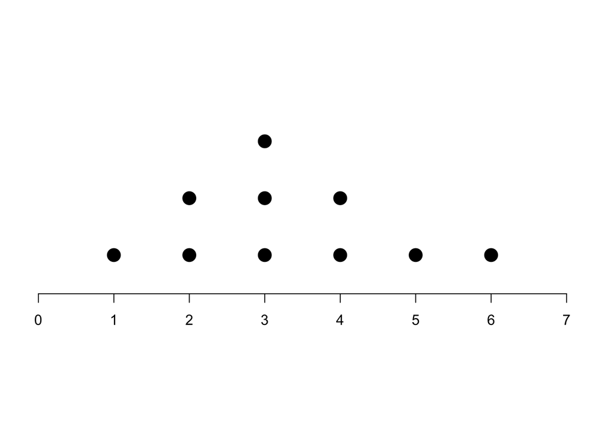